# index

## Introduction to `napari`

**Peter Sobolewski (he/him)**

Systems Analyst Imaging Applications & Machine Learning Research IT

### https://napari.org

[figure not shown]

**COI Disclaimer: Peter is a napari core developer**

## Plan

- Introduction to napari (these slides)
- napari application: the GUI
  - napari console: integrated Python REPL
- exploratory image analysis with napari and Jupyter lab
  - Image layers: visualization
  - Points, Shapes, Labels layers: annotation
  - Example workflow

## What is napari?

A Python library for n-dimensional image visualization, annotation, and analysis.

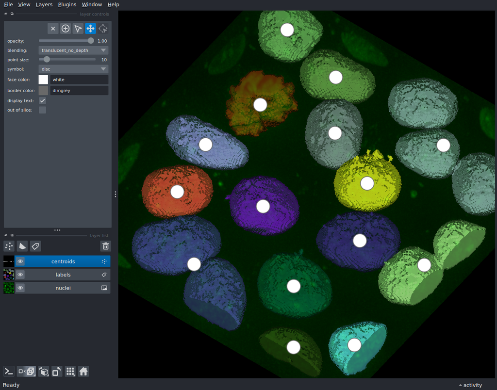

## What can napari be used for?

- view & explore 2D, 3D, and higher-dimensional arrays
- overlay derived data such as points, polygons, labels, and more
- seamlessly weave exploration, computation, and annotation together in imaging data analysis
- leverage scientific Python ecosystem

## A bit of background

- started in 2018 by Loïc Royer (Chan Zuckerberg Biohub) and Juan Nunez-Iglesias (Monash University)
- goal: fast n-dimensional image viewer for Python
- named after [a settlement in Kiribati in the South Pacific, the approx. midpoint between San Francisco and Melbourne](https://en.wikipedia.org/wiki/Napari)
- since then, the project has grown considerably, with >150 contributors and >500 plugins

For more backstory, [check out Juan’s blog post](https://ilovesymposia.com/2019/10/24/introducing-napari-a-fast-n-dimensional-image-viewer-in-python/)—JAX is part of it!

## napari strengths

- graphical UI to view & explore 2D, 3D, and higher-dimensional array-like data
  - easy to integrate into existing Python workflows
- intuitive stacking/overlay layer model for channels, modalities, annotations, etc.
- robust GUI data annotation tools
  - annotation data immediately available as Python objects
- highly extensible GUI
- robust plugin ecosystem: https://napari-hub.org

## napari limitations

- **it’s just a viewer & annotation tool**
  - **no built-in analysis tools** (but you have Python!)
- not yet feature complete
  - no parity between different layers/features (e.g. multiscale handling)
  - there can be bugs 🪲
- can run into GPU/memory limitations for some large-data workflows
- Python packaging and dependencies 😬

## napari is an open-source, community developed project—anyone can contribute!

### Even me—or *you*!

- Visit the GitHub repository: https://github.com/napari/napari

## Where to get help

- napari documentation: https://napari.org
- image.sc forum: https://forum.image.sc/tag/napari
- napari Zulip chat: https://napari.zulipchat.com
- napari community meetings: https://napari.org/stable/community/meeting_schedule.html

No accounts are needed to lurk…

## Report bugs

- GitHub Issues: https://github.com/napari/napari/issues
- Reporting bugs/problems/inconsistencies/confusion is **extremely valuable!**
- When in doubt, report—we prefer duplicates than crickets!

This does require an account (free), **but you can use that account to login at image.sc and zulipchat.com!**

# Exploring the napari viewer GUI

## napari viewer

- native application you can launch from the terminal/command prompt using `napari` command or via the application programming interface (API), e.g. `viewer = napari.Viewer()`

**Tip**

The [napari bundled application](https://napari.org/stable/tutorials/fundamentals/installation.html#install-as-a-bundled-app) is stand alone and can be launched from your OS GUI

- this `viewer` consists of menus, a `canvas` used for display, and widgets with controls for interacting with what is displayed on the `canvas`

## napari viewer

[figure not shown]

## napari viewer: Preferences

[figure not shown]

**Access via `File` menu (`napari` on macOS)**

- Extensive, editable keyboard shortcuts!
- Stored per Python env, reset using `napari --reset`

## Plugins can be installed from within napari

- plugins can be publically discoverable and have global reach via PyPI/conda-forge and napari-hub.org

[figure not shown]

## napari layers

- the napari visualization data model uses `layers`
- each `layer` (an image or annotation) is composited as a overlay on the previous one, with different opacity and blending options
- the `LayerList` widget allows you to toggle visibility and stacking order
- the `LayerControls` widget allows you to change visualization settings of a selected layer

## napari layers

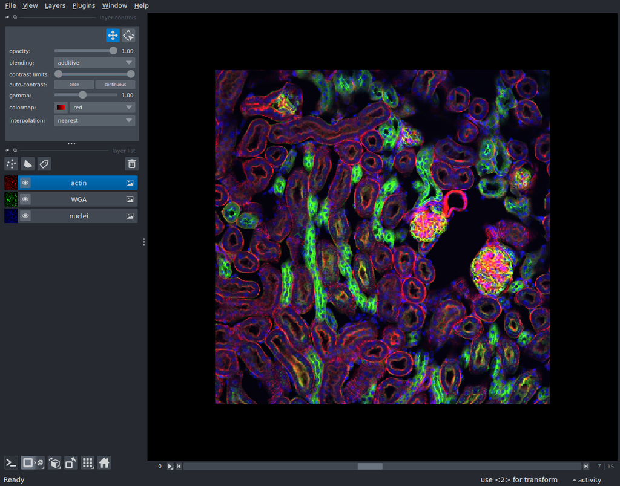

## Dimensions in napari

- by default, 2 dimensions are displayed: the last two (right-most) axes of an array
- non-displayed dimensions will be represented using a slider
- 3D display can be toggled using viewer button or API
- axes can be rotated or transposed using viewer buttons or API

## Dimensions in napari

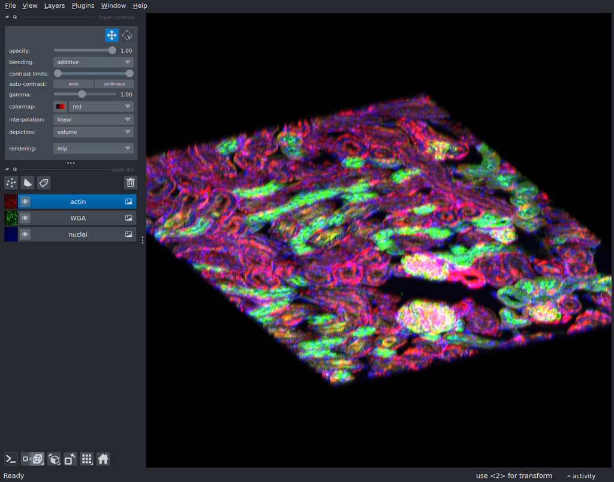

# The napari API

# Headless napari is just Python!

### – Juan Nunez-Iglesias (**@jni**)

## Interact with napari using the built-in Python console

[figure not shown]

**Only available when launched from a non-interactive environment**

## Run napari from scripts or notebooks

**expand for full code**

```python
from skimage import data
from scipy import ndimage as ndi

import napari

blobs = data.binary_blobs(length=128, volume_fraction=0.1, n_dim=3)
labeled = ndi.label(blobs)[0]
viewer, image_layer = napari.imshow(blobs, name='blobs')
viewer.add_labels(labeled, name='blob ID')
viewer.dims.ndisplay = 3
viewer.camera.zoom = 3
viewer.camera.angles = (3, 38, 53)

if __name__ == '__main__':
    napari.run()
```

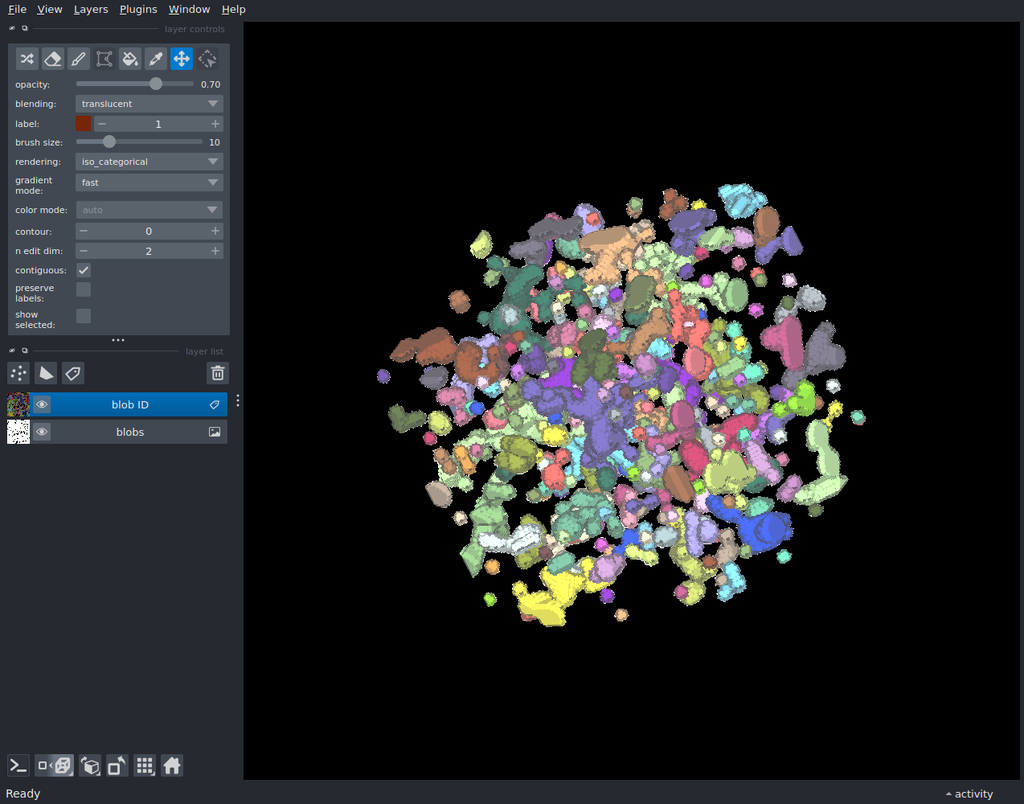

## napari API

- the API and the GUI are bidirectional:
  - GUI changes are reflected in object property changes
  - API changes are reflected in the GUI

**This is even true for annotations, like Point positions or Shape vectors**

- if you’re not using an interactive environment, you can access it using the built-in `console`
- napari was designed to be extensible

## Python scripts can handle keyboard and mouse events!

- Customize napari functionality:
  - keyboard and mouse events: https://napari.org/stable/howtos/connecting_events.html

```python
@viewer.bind_key('a')
def accept_image(viewer):
    msg = 'this is a good image'
    viewer.status = msg
    print(msg)
```

- Example: [https://napari.org/stable/gallery/custom_mouse_functions.html](https://napari.org/stable/gallery/custom_mouse_functions.html#sphx-glr-gallery-custom-mouse-functions-py)

## Python scripts can contribute widgets!

[figure not shown]

Example: https://napari.org/stable/gallery/magic_parameter_sweep.html

## Python scripts can contribute widgets!

- [`magicgui`](https://pyapp-kit.github.io/magicgui/) makes this quite easy, see https://napari.org/stable/guides/magicgui.html
- …but you can also use `Qt` for maximal control by subclassing `QWidget`

## Beyond that, can develop a napari plugin

napari plugins are Python packages that can:

- add file-type readers & writers
- customize functionality (events)
- extend the GUI (widgets, menus)
- provide demo/sample data

Plugin developer guide: https://napari.org/dev/plugins/index.html